# Adipose male-female concordance across timepoints

2026-06-25

## Motivation

This is a focused companion to `sex_sensitivity_analysis.Rmd`. The summary matrix in that document deliberately drops adipose (`tissue != "adipose"`), and the per-tissue scatter deep dive there is built around blood. Adipose, however, shows the single most *timepoint-dependent* sex concordance pattern in the whole dataset, so it deserves its own treatment.

In the existing overall correlation table (`outputs/m_vs_f_response_correlation.csv`), the adipose transcriptome looks like this:

| Group | Timepoint | n sig | Pearson r |
| --- | --- | --- | --- |
| EE | P15-45M | 57 | 0.93 |
| RE | P15-45M | 34 | 0.87 |
| RE | P3.5/4H | 31 | **-0.09** |
| EE | P3.5/4H | 3 | 0.94 (n=3) |
| EE | P24H | 3 | 0.75 (n=3) |

So at the early post-exercise window (P15-45M) male and female adipose responses are highly concordant in both exercise modes, but by 3.5/4 h the resistance-exercise concordance has collapsed to essentially zero. The questions this document addresses:

1. **Across timepoints, how concordant are the male and female adipose responses?**
2. **Which features drive the divergence at the discordant cells?**

Everything here is descriptive and hypothesis-generating: the per-sex sample sizes are small, so single discordant cells should be read as candidates for follow-up, not confirmed dimorphism.

## Concordance metrics used here

- **Pearson’s r** — do the two sexes rank features the same way (direction + relative magnitude)?
- **Sign concordance** — the fraction of features for which both sexes move in the same direction.

```r
sign_concordance = function(x, y) {
  ok = is.finite(x) & is.finite(y)
  x = x[ok]; y = y[ok]
  if (length(x) == 0) return(NA_real_)
  mean(sign(x) == sign(y))
}

# concordance summary per Group x Timepoint; expects logFC_Female / logFC_Male columns
concordance_table = function(df_wide) {
  df_wide %>%
    dplyr::group_by(Ome, Group, Timepoint) %>%
    dplyr::summarise(
      n_sig      = dplyr::n(),
      Pearsons_R = cor(logFC_Female, logFC_Male, use = "complete.obs"),
      sign_conc  = sign_concordance(logFC_Female, logFC_Male),
      slope      = tryCatch(coef(lm(logFC_Male ~ logFC_Female))[2],
                            error = function(e) NA_real_),
      .groups = "drop"
    )
}
```

## Loading the pre-computed sex-stratified tables

The sex-stratified tables are built once in `sex_sensitivity_analysis.Rmd` and exported as RDS (`scatter_wide.rds`, one row per feature with male/female logFC; `precawg_and_m_vs_f_diff.rds`, the direct male-vs-female sex-difference contrast joined to PreCAWG). Here we just load them and restrict to adipose. The object loaded into `precawg_and_sex_diff` is named to match the default argument of `sex_differences_logfc_feature()`.

```r
scatter_wide = readRDS(file.path(out_dir, "scatter_wide.rds")) %>%
  dplyr::filter(tissue == "adipose")

precawg_and_sex_diff = readRDS(file.path(out_dir, "precawg_and_m_vs_f_diff.rds")) %>%
  dplyr::filter(tissue == "adipose")
```

# 1. What adipose data can we actually assess?

Before interpreting concordance we need to know how many male and female participants contribute to each adipose group × timepoint. Thin cells produce fragile concordance estimates.

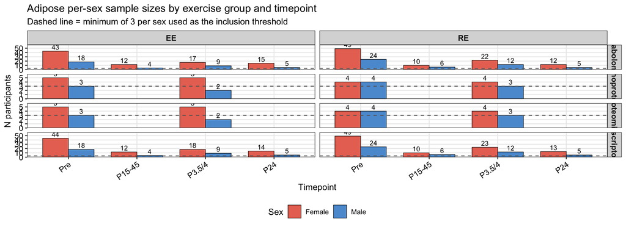

```r
adipose_qc = MotrpacHumanPreSuspensionData::load_qc(selected_tissues = "adipose")[["adipose"]]

pheno_meta = MotrpacHumanPreSuspensionData::pheno$data %>%
  dplyr::select(vialLabel, Sex, randomGroupCode, Timepoint) %>%
  dplyr::mutate(vialLabel = as.character(vialLabel))

adipose_counts = lapply(names(adipose_qc), function(ome) {
  mat = adipose_qc[[ome]][["qc_norm"]]
  if (is.null(mat)) return(NULL)
  tibble::tibble(vialLabel = as.character(colnames(mat)), assay = ome)
}) %>%
  dplyr::bind_rows() %>%
  dplyr::inner_join(pheno_meta, by = "vialLabel") %>%
  dplyr::filter(!grepl("metab", assay) | assay == "metab-u-hilicpos") %>%
  dplyr::group_by(assay, randomGroupCode, Timepoint, Sex) %>%
  dplyr::summarise(n = dplyr::n(), .groups = "drop")

timepoint_short = c(
  "pre_exercise"      = "Pre",
  "during_20_min"     = "D20",
  "during_40_min"     = "D40",
  "post_10_min"       = "P10",
  "post_15_30_45_min" = "P15-45",
  "post_3.5_4_hr"     = "P3.5/4",
  "post_24_hr"        = "P24"
)
sex_colors = c(Female = "#E87461", Male = "#5B9BD5")

adipose_counts_plot = adipose_counts %>%
  dplyr::filter(randomGroupCode != "ADUControl") %>%
  dplyr::mutate(
    Group = dplyr::recode(randomGroupCode, "ADUEndur" = "EE", "ADUResist" = "RE"),
    tp = factor(dplyr::recode(as.character(Timepoint), !!!timepoint_short),
                levels = unname(timepoint_short)),
    Ome = dplyr::case_when(
      grepl("metab", assay) ~ "Metabolomics",
      grepl("rna", assay)   ~ "Transcriptomics",
      assay == "prot-ph"    ~ "Phosphoproteomics",
      assay %in% c("prot-pr", "prot-ol") ~ "Proteomics",
      TRUE ~ assay
    )
  )

ggplot(adipose_counts_plot, aes(x = tp, y = n, fill = Sex)) +
  geom_col(position = "dodge", color = "black", linewidth = 0.25, width = 0.75) +
  geom_text(aes(label = n), position = position_dodge(width = 0.75),
            vjust = -0.35, size = 3) +
  geom_hline(yintercept = 3, linetype = "dashed", color = "grey40") +
  facet_grid(Ome ~ Group, scales = "free_y") +
  scale_fill_manual(values = sex_colors) +
  scale_y_continuous(expand = expansion(mult = c(0, 0.18))) +
  labs(x = "Timepoint", y = "N participants",
       title = "Adipose per-sex sample sizes by exercise group and timepoint",
       subtitle = "Dashed line = minimum of 3 per sex used as the inclusion threshold") +
  theme_bw(base_size = 11) +
  theme(strip.text = element_text(size = 10, face = "bold"),
        axis.text = element_text(size = 10, color = "black"),
        axis.text.x = element_text(angle = 35, hjust = 1),
        panel.grid.minor = element_blank(),
        legend.position = "bottom")
```

```r
ggsave(file.path(out_dir, "adipose_sample_counts.png"),
       width = 11, height = 4, dpi = 600)
```

# 2. Concordance by timepoint

```r
adipose_sig = scatter_wide %>%
  dplyr::filter(!is.na(pre_cawg_adj_p), pre_cawg_adj_p < 0.05, Group %in% c("EE", "RE"))

adipose_concordance = concordance_table(adipose_sig) %>%
  dplyr::arrange(Ome, Group, Timepoint)

knitr::kable(
  adipose_concordance %>%
    dplyr::transmute(
      Ome, Group, Timepoint, n_sig,
      `Pearson r`   = round(Pearsons_R, 2),
      `Sign conc.`  = round(sign_conc, 2),
      slope         = round(slope, 2)
    ),
  caption = "Adipose male-female concordance of exercise logFC (PreCAWG-significant features), per group and timepoint."
)
```

Adipose male-female concordance of exercise logFC (PreCAWG-significant features), per group and timepoint.

| Ome | Group | Timepoint | n_sig | Pearson r | Sign conc. | slope |
| --- | --- | --- | --- | --- | --- | --- |
| Transcriptomics | EE | post_15_30_45_min | 57 | 0.93 | 0.96 | 1.15 |
| Transcriptomics | EE | post_3.5_4_hr | 3 | 0.94 | 1.00 | 0.92 |
| Transcriptomics | EE | post_24_hr | 3 | 0.75 | 1.00 | 1.86 |
| Transcriptomics | RE | post_15_30_45_min | 34 | 0.87 | 1.00 | 1.30 |
| Transcriptomics | RE | post_3.5_4_hr | 31 | -0.08 | 0.97 | -0.07 |
| Metabolomics | EE | post_15_30_45_min | 1 | NA | 1.00 | NA |
| Metabolomics | EE | post_3.5_4_hr | 52 | -0.07 | 1.00 | -0.18 |
| Metabolomics | EE | post_24_hr | 1 | NA | 1.00 | NA |
| Metabolomics | RE | post_15_30_45_min | 1 | NA | 1.00 | NA |

```r
write.csv(adipose_concordance,
          file.path(out_dir, "adipose_concordance_by_timepoint.csv"),
          row.names = FALSE)
```

# 3. Per-timepoint male-vs-female logFC scatter

The scatter makes the structure behind each correlation visible: at P15-45M the cloud hugs the identity line in both modes, whereas RE P3.5/4H is diffuse with no coherent direction. The most sex-divergent transcripts at RE P3.5/4H (smallest sex-difference adjusted *p*-value) are labeled in every panel for reference, following the blood scatter in `sex_sensitivity_analysis.Rmd`.

```r
# Top 10 most sex-divergent features at the discordant cell (RE, P3.5/4H).
highlight_ids = precawg_and_sex_diff %>%
  dplyr::filter(assay == "transcript-rna-seq",
                randomGroupCode == "ADUResist",
                Timepoint == "post_3.5_4_hr") %>%
  dplyr::slice_min(adj_p_value_sex_diff, n = 10, with_ties = FALSE) %>%
  dplyr::pull(feature_id)
```

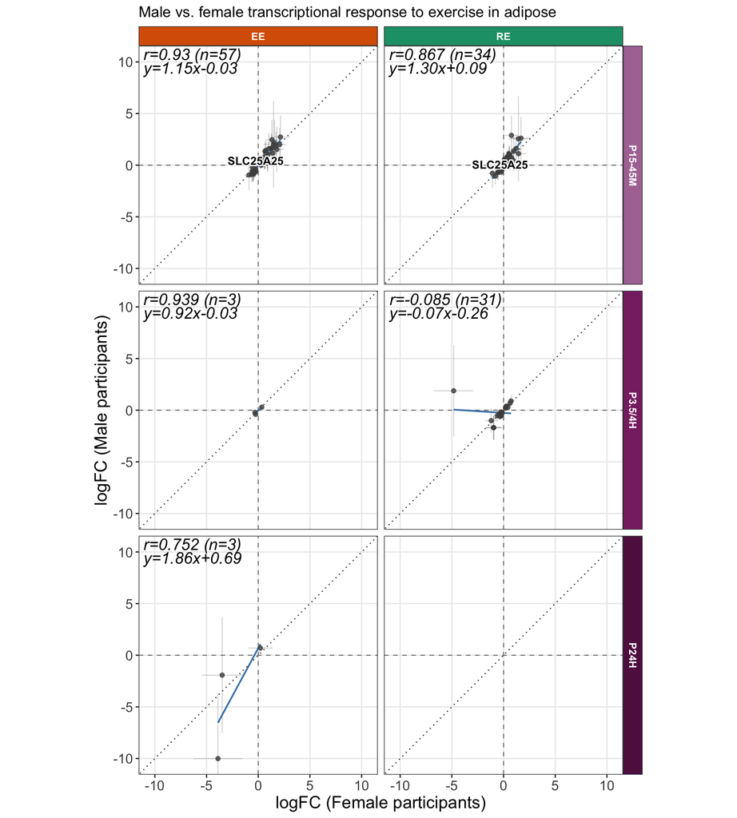

```r
adipose_tp_labels = c(
  "post_15_30_45_min" = "P15-45M",
  "post_3.5_4_hr"     = "P3.5/4H",
  "post_24_hr"        = "P24H"
)

prettify_adipose = function(df) {
  df %>%
    dplyr::mutate(
      Timepoint = factor(dplyr::recode(as.character(Timepoint), !!!adipose_tp_labels),
                         levels = unname(adipose_tp_labels)),
      Group = factor(Group, levels = c("EE", "RE"))
    )
}

scatter_post = adipose_sig %>%
  dplyr::filter(Timepoint %in% names(adipose_tp_labels)) %>%
  prettify_adipose()

# minimal cor frame in the shape .make_sex_scatter() expects
scatter_cor = adipose_concordance %>%
  dplyr::mutate(tissue = "adipose", Pearsons_R = round(Pearsons_R, 3)) %>%
  dplyr::filter(Timepoint %in% names(adipose_tp_labels)) %>%
  prettify_adipose() %>%
  dplyr::select(Ome, tissue, Group, Timepoint, n_sig, Pearsons_R)

p_scatter = .make_sex_scatter("adipose", "Transcriptomics", scatter_post, scatter_cor,
                              highlight_ids = highlight_ids)
if (!is.null(p_scatter)) {
  p_scatter = p_scatter +
    labs(title = "Male vs. female transcriptional response to exercise in adipose")
  print(p_scatter)
  ggsave(file.path(out_dir, "scatter_adipose_EE_RE_post.png"),
         plot = p_scatter, width = 9, height = 10, dpi = 600, units = "in")
}
```

**Figure legend.** *Sex-stratified adipose transcriptional response across post-exercise timepoints.* Each point is a transcript significant in the primary sex-combined PreCAWG differential analysis (BH-adjusted *p* < 0.05); female logFC on the x-axis, male logFC on the y-axis, with 95% CI bars. Rows are post-exercise timepoints, columns are exercise mode (EE, endurance; RE, resistance). The dotted diagonal is the line of identity and the blue line is the OLS fit. Labeled transcripts are the 10 most sex-divergent features in resistance exercise at 3.5/4 h, shown in every panel. Note the sparse EE P3.5/4H and P24H panels (n = 3 each), which should not be over-interpreted.

## Metabolomics scatter

The same scatter for the adipose metabolome. Metabolites are pooled across all targeted and untargeted platforms (`assay == "metab"`). Because the discordant window need not coincide with the transcriptomic one, the labeled metabolites are the most sex-divergent features at whichever post-exercise cell has the lowest male-female concordance (lowest Pearson *r* among cells with at least five significant metabolites).

```r
# Data-driven pick of the most discordant post-exercise metabolomics cell, then label its
# most sex-divergent metabolites (smallest sex-difference adjusted p) in every panel.
metab_discordant = adipose_concordance %>%
  dplyr::filter(Ome == "Metabolomics",
                Timepoint %in% names(adipose_tp_labels),
                n_sig >= 5) %>%
  dplyr::arrange(Pearsons_R) %>%
  dplyr::slice(1)

metab_highlight_group = NA_character_
metab_highlight_ids = character(0)
if (nrow(metab_discordant) == 1) {
  metab_highlight_group = dplyr::recode(metab_discordant$Group,
                                        "EE" = "ADUEndur", "RE" = "ADUResist")
  metab_highlight_ids = precawg_and_sex_diff %>%
    dplyr::filter(assay == "metab",
                  randomGroupCode == metab_highlight_group,
                  Timepoint == metab_discordant$Timepoint) %>%
    dplyr::slice_min(adj_p_value_sex_diff, n = 10, with_ties = FALSE) %>%
    dplyr::pull(feature_id)
}
```

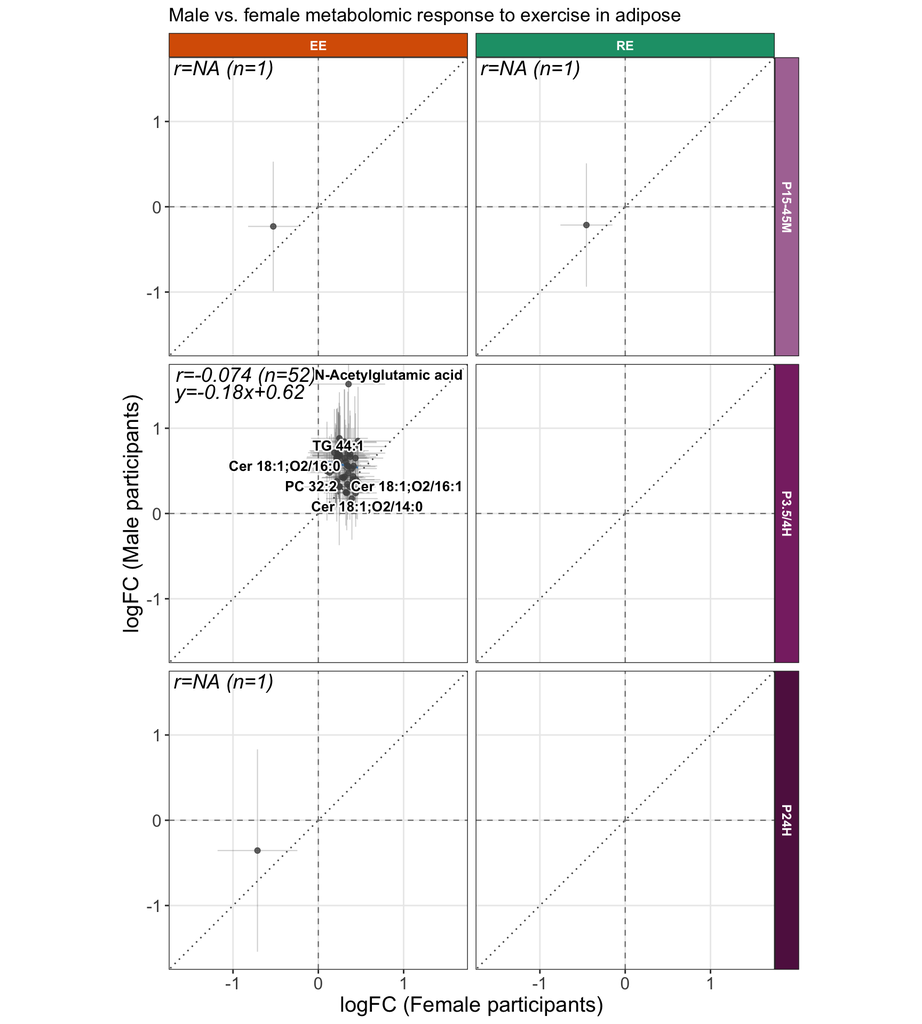

```r
p_scatter_metab = .make_sex_scatter("adipose", "Metabolomics", scatter_post, scatter_cor,
                                    highlight_ids = metab_highlight_ids)
if (!is.null(p_scatter_metab)) {
  p_scatter_metab = p_scatter_metab +
    labs(title = "Male vs. female metabolomic response to exercise in adipose")
  print(p_scatter_metab)
  ggsave(file.path(out_dir, "scatter_adipose_EE_RE_post_metab.png"),
         plot = p_scatter_metab, width = 9, height = 10, dpi = 600, units = "in")
}
```

**Figure legend.** *Sex-stratified adipose metabolomic response across post-exercise timepoints.* As above, but each point is a metabolite significant in the primary sex-combined PreCAWG differential analysis (BH-adjusted *p* < 0.05), pooled across all adipose metabolomics platforms; female logFC on the x-axis, male logFC on the y-axis, with 95% CI bars. Labeled metabolites are the 10 most sex-divergent features at the most discordant post-exercise cell. As with the transcriptome, per-sex sample sizes are small and thin cells should be read as suggestive only.

# 4. Which features diverge most?

```r
annotated = precawg_and_sex_diff %>%
  dplyr::left_join(
    HUMAN_FEATURE_TO_GENE %>% dplyr::filter(assay == "transcript-rna-seq"),
    by = c("feature_id", "assay")
  )

divergent = annotated %>%
  dplyr::filter(assay == "transcript-rna-seq",
                randomGroupCode == "ADUResist",
                Timepoint == "post_3.5_4_hr",
                adj_p_value_precawg < 0.05,
                adj_p_value_sex_diff < 0.05) %>%
  dplyr::arrange(adj_p_value_sex_diff)

# Annotate gene location (chrX, chrY, chr1, ...) so any sex-chromosome enrichment
# among the divergent features is obvious. Mapped by Ensembl gene ID (the rna-seq
# feature identifier) rather than HGNC symbol; falls back to NA if biomaRt is
# unavailable.
divergent_ensembl = unique(as.character(divergent$ensembl_gene))
divergent_ensembl = divergent_ensembl[!is.na(divergent_ensembl)]

ensembl = tryCatch(
  biomaRt::useEnsembl("ensembl", dataset = "hsapiens_gene_ensembl"),
  error = function(e) {
    message("biomaRt unavailable, skipping chromosome annotation: ", e$message)
    NULL
  }
)

chrom_annotation = NULL
if (!is.null(ensembl) && length(divergent_ensembl) > 0) {
  chrom_annotation = biomaRt::getBM(
    attributes = c("ensembl_gene_id", "chromosome_name"),
    filters    = "ensembl_gene_id",
    values     = divergent_ensembl,
    mart       = ensembl
  ) %>%
    dplyr::filter(chromosome_name %in% c(as.character(1:22), "X", "Y")) %>%
    dplyr::distinct(ensembl_gene_id, chromosome_name)
}

divergent = divergent %>%
  dplyr::mutate(ensembl_gene = as.character(ensembl_gene)) %>%
  dplyr::left_join(
    if (!is.null(chrom_annotation)) chrom_annotation else
      data.frame(ensembl_gene_id = character(), chromosome_name = character()),
    by = c("ensembl_gene" = "ensembl_gene_id")
  ) %>%
  dplyr::mutate(location = dplyr::if_else(is.na(chromosome_name),
                                          NA_character_, paste0("chr", chromosome_name)))

write.csv(divergent,
          file.path(out_dir, "divergent_adipose_RE_P35_rna.csv"), row.names = FALSE)

knitr::kable(
  divergent %>%
    dplyr::transmute(gene_symbol,
                     location,
                     `male-female logFC` = round(logFC_sex_diff, 2),
                     adj_p_value_sex_diff = signif(adj_p_value_sex_diff, 2),
                     adj_p_value_precawg = signif(adj_p_value_precawg, 2)) %>%
    head(25),
  caption = "Top adipose transcripts diverging between sexes in RE at 3.5/4 h post-exercise (male minus female logFC), with gene location."
)
```

Top adipose transcripts diverging between sexes in RE at 3.5/4 h post-exercise (male minus female logFC), with gene location.

| gene_symbol | location | male-female logFC | adj_p_value_sex_diff | adj_p_value_precawg |
| --- | --- | --- | --- | --- |
| NA | chr21 | -2.75 | 0.0098 | 0.033 |
| NA | chr21 | -2.75 | 0.0098 | 0.033 |
| NA | chr21 | -2.75 | 0.0098 | 0.033 |
| HERC6 | chr4 | -0.81 | 0.0110 | 0.011 |

The three features lacking a gene symbol all map to a single repeat-rich window on the chr21 short arm (~8.2–8.4 Mb) and are annotated as near-identical lncRNAs similar to *YAM1*:

| Ensembl ID | chr21 position (GRCh38) | Length | Biotype | Annotation |
| --- | --- | --- | --- | --- |
| ENSG00000280614 | 8,393,419–8,394,341 | ~922 bp | lncRNA | “novel transcript, similar to YAM1” |
| ENSG00000280800 | 8,210,384–8,211,306 | ~922 bp | lncRNA | “novel transcript, similar to YAM1” |
| ENSG00000281181 | 8,437,629–8,438,551 | ~922 bp | lncRNA | “novel transcript, similar to YAM1” |

## Which metabolites diverge most?

The metabolomic analogue: metabolites that are both responsive (PreCAWG-significant) and significantly different between males and females at the most discordant metabolomics cell identified above. There is no chromosome annotation to add here, so we report the RefMet name, the platform the metabolite was measured on, and the size and direction of the sex difference (male minus female logFC).

```r
if (nrow(metab_discordant) == 1) {
  divergent_metab = precawg_and_sex_diff %>%
    dplyr::filter(assay == "metab",
                  randomGroupCode == metab_highlight_group,
                  Timepoint == metab_discordant$Timepoint,
                  adj_p_value_precawg < 0.05,
                  adj_p_value_sex_diff < 0.05) %>%
    dplyr::arrange(adj_p_value_sex_diff)

  write.csv(divergent_metab,
            file.path(out_dir, "divergent_adipose_metab.csv"), row.names = FALSE)

  knitr::kable(
    divergent_metab %>%
      dplyr::transmute(metabolite = feature_id,
                       platform,
                       `male-female logFC` = round(logFC_sex_diff, 2),
                       adj_p_value_sex_diff = signif(adj_p_value_sex_diff, 2),
                       adj_p_value_precawg = signif(adj_p_value_precawg, 2)) %>%
      head(25),
    caption = sprintf(
      "Top adipose metabolites diverging between sexes in %s at %s (male minus female logFC).",
      metab_discordant$Group, metab_discordant$Timepoint)
  )
} else {
  cat("No adipose metabolomics cell cleared the minimum-feature threshold for a divergence table.")
}
```

Top adipose metabolites diverging between sexes in EE at post_3.5_4_hr (male minus female logFC).

| metabolite | platform | male-female logFC | adj_p_value_sex_diff | adj_p_value_precawg |
| --- | --- | --- | --- | --- |
| N-Acetylglutamic acid | metab-u-hilicpos | 1.52 | 0.037 | 0.0039 |